# The Analytics Edge Week 1

Joona Rauhamäki

huhtikuuta 2016

# The Analytics Edge Week 1

## Assignment II STOCK DYNAMICS

A stock market is where buyers and sellers trade shares of a company, and is one of the most popular ways for individuals and companies to invest money. The size of the world stock market is now estimated to be in the trillions. The largest stock market in the world is the New York Stock Exchange (NYSE), located in New York City. About 2,800 companies are listed on the NSYE. In this problem, we’ll look at the monthly stock prices of five of these companies: IBM, General Electric (GE), Procter and Gamble, Coca Cola, and Boeing. The data used in this problem comes from Infochimps.

Download and read the following files into R, using the read.csv function: IBMStock.csv, GEStock.csv, ProcterGambleStock.csv, CocaColaStock.csv, and BoeingStock.csv. (Do not open these files in any spreadsheet software before completing this problem because it might change the format of the Date field.)

Call the data frames “IBM”, “GE”, “ProcterGamble”, “CocaCola”, and “Boeing”, respectively. Each data frame has two variables, described as follows:

Date: the date of the stock price, always given as the first of the month. StockPrice: the average stock price of the company in the given month. In this problem, we’ll take a look at how the stock dynamics of these companies have changed over time.

Let’s start by emptying the workspace:

```r
rm (list = ls(all=T))
```

```r
IBM = read.csv("IBMStock.csv")
GE = read.csv("GEStock.csv")
ProcterGamble = read.csv("ProcterGambleStock.csv")
CocaCola = read.csv("CocaColaStock.csv")
Boeing = read.csv("BoeingStock.csv")
```

### Problem 1.1 - Summary Statistics

(1 point possible) Before working with these data sets, we need to convert the dates into a format that R can understand. Take a look at the structure of one of the datasets using the str function. Right now, the date variable is stored as a factor. We can convert this to a “Date” object in R by using the following five commands (one for each data set):

```r
IBM$Date = as.Date(IBM$Date, "%m/%d/%y")

GE$Date = as.Date(GE$Date, "%m/%d/%y")

CocaCola$Date = as.Date(CocaCola$Date, "%m/%d/%y")

ProcterGamble$Date = as.Date(ProcterGamble$Date, "%m/%d/%y")

Boeing$Date = as.Date(Boeing$Date, "%m/%d/%y")
```

The first argument to the as.Date function is the variable we want to convert, and the second argument is the format of the Date variable. We can just overwrite the original Date variable values with the output of this function. Now, answer the following questions using the str and summary functions.

Our five datasets all have the same number of observations. How many observations are there in each data set?

```r
nrow(IBM)
```

```
## [1] 480
```

### Problem 1.2 - Summary Statistics

What is the earliest year in our datasets?

```r
str(IBM)
```

```
## 'data.frame':    480 obs. of  2 variables:
##  $ Date      : Date, format: "1970-01-01" "1970-02-01" ...
##  $ StockPrice: num  360 347 327 320 270 ...
```

```r
str(GE)
```

```
## 'data.frame':    480 obs. of  2 variables:
##  $ Date      : Date, format: "1970-01-01" "1970-02-01" ...
##  $ StockPrice: num  74.3 70 72.2 74.3 66.7 ...
```

```r
str(CocaCola)
```

```
## 'data.frame':    480 obs. of  2 variables:
##  $ Date      : Date, format: "1970-01-01" "1970-02-01" ...
##  $ StockPrice: num  83.4 81.6 81.3 76.8 69.3 ...
```

```r
str(ProcterGamble)
```

```
## 'data.frame':    480 obs. of  2 variables:
##  $ Date      : Date, format: "1970-01-01" "1970-02-01" ...
##  $ StockPrice: num  111.9 111.5 108.5 106.3 73.3 ...
```

```r
str(Boeing)
```

```
## 'data.frame':    480 obs. of  2 variables:
##  $ Date      : Date, format: "1970-01-01" "1970-02-01" ...
##  $ StockPrice: num  27.9 22.4 23.1 21.6 18.9 ...
```

### Problem 1.3 - 1.7 Summary Statistics

What is the latest year in our datasets? What is the mean stock price of IBM over this time period? What is the minimum stock price of General Electric (GE) over this time period? What is the median stock price of Boeing over this time period?

```r
summary(IBM)
```

```
##       Date              StockPrice
##  Min.   :1970-01-01   Min.   : 43.40
##  1st Qu.:1979-12-24   1st Qu.: 88.34
##  Median :1989-12-16   Median :112.11
##  Mean   :1989-12-15   Mean   :144.38
##  3rd Qu.:1999-12-08   3rd Qu.:165.41
##  Max.   :2009-12-01   Max.   :438.90
```

```r
summary(GE)
```

```
##       Date              StockPrice
##  Min.   :1970-01-01   Min.   :  9.294
##  1st Qu.:1979-12-24   1st Qu.: 44.214
##  Median :1989-12-16   Median : 55.812
##  Mean   :1989-12-15   Mean   : 59.303
##  3rd Qu.:1999-12-08   3rd Qu.: 72.226
##  Max.   :2009-12-01   Max.   :156.844
```

```r
summary(CocaCola)
```

```
##       Date              StockPrice
##  Min.   :1970-01-01   Min.   : 30.06
##  1st Qu.:1979-12-24   1st Qu.: 42.76
##  Median :1989-12-16   Median : 51.44
##  Mean   :1989-12-15   Mean   : 60.03
##  3rd Qu.:1999-12-08   3rd Qu.: 69.62
##  Max.   :2009-12-01   Max.   :146.58
```

```r
summary(ProcterGamble)
```

```
##       Date              StockPrice
##  Min.   :1970-01-01   Min.   : 46.88
##  1st Qu.:1979-12-24   1st Qu.: 62.48
##  Median :1989-12-16   Median : 78.34
##  Mean   :1989-12-15   Mean   : 77.70
##  3rd Qu.:1999-12-08   3rd Qu.: 89.47
##  Max.   :2009-12-01   Max.   :149.62
```

```r
summary(Boeing)
```

```
##       Date              StockPrice
##  Min.   :1970-01-01   Min.   : 12.74
##  1st Qu.:1979-12-24   1st Qu.: 34.64
##  Median :1989-12-16   Median : 44.88
##  Mean   :1989-12-15   Mean   : 46.59
##  3rd Qu.:1999-12-08   3rd Qu.: 57.21
##  Max.   :2009-12-01   Max.   :107.28
```

What is the standard deviation of the stock price of Procter & Gamble over this time period?

```r
sd(ProcterGamble$StockPrice)
```

```
## [1] 18.19414
```

### Problem 2.1 - Visualizing Stock Dynamics

Let’s plot the stock prices to see if we can visualize trends in stock prices during this time period. Using the plot function, plot the Date on the x-axis and the StockPrice on the y-axis, for Coca-Cola.

This plots our observations as points, but we would really like to see a line instead, since this is a continuous time period. To do this, add the argument type=“l” to your plot command, and re-generate the plot (the character is quotes is the letter l, for line). You should now see a line plot of the Coca-Cola stock price.

Around what year did Coca-Cola has its highest stock price in this time period?

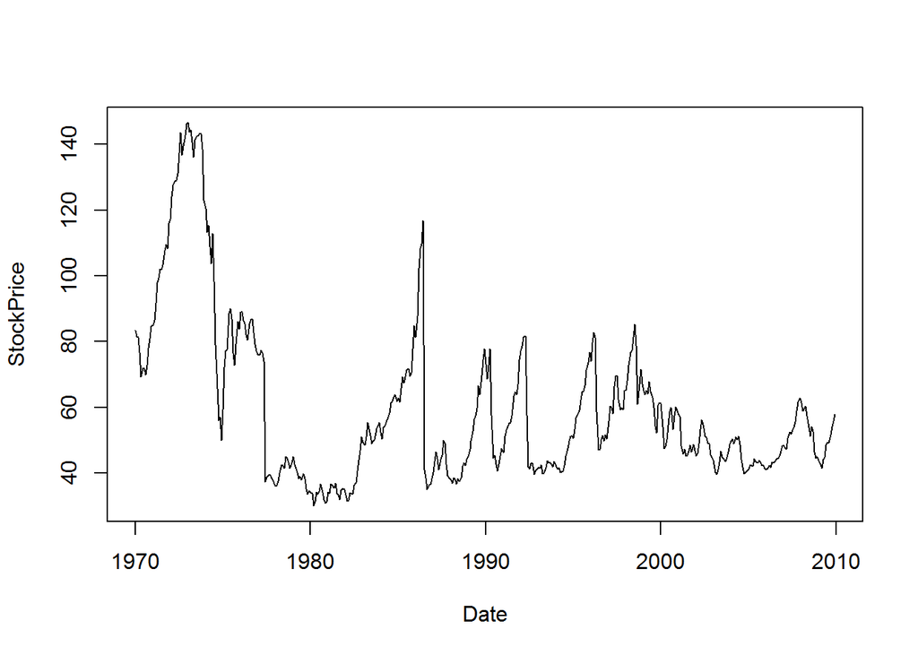

```r
plot(CocaCola, type = "l")
```

### Problem 2.2 - Visualizing Stock Dynamics

Now, let’s add the line for Procter & Gamble too. You can add a line to a plot in R by using the lines function instead of the plot function. Keeping the plot for Coca-Cola open, type in your R console:

lines(ProcterGamble$Date, ProcterGamble$StockPrice)

Unfortunately, it’s hard to tell which line is which. Let’s fix this by giving each line a color. First, re-run the plot command for Coca-Cola, but add the argument col=“red”. You should see the plot for Coca-Cola show up again, but this time in red. Now, let’s add the Procter & Gamble line (using the lines function like we did before), adding the argument col=“blue”. You should now see in your plot the Coca-Cola stock price in red, and the Procter & Gamble stock price in blue.

As an alternative choice to changing the colors, you could instead change the line type of the Procter & Gamble line by adding the argument lty=2. This will make the Procter & Gamble line dashed.

Using this plot, answer the following questions.

In March of 2000, the technology bubble burst, and a stock market crash occurred. According to this plot, which company’s stock dropped more?

To answer this question and the ones that follow, you may find it useful to draw a vertical line at a certain date. To do this, type the command

abline(v=as.Date(c(“2000-03-01”)), lwd=2)

in your R console, with the plot still open. This generates a vertical line at the date March 1, 2000. The argument lwd=2 makes the line a little thicker. You can change the date in this command to generate the vertical line in different locations.

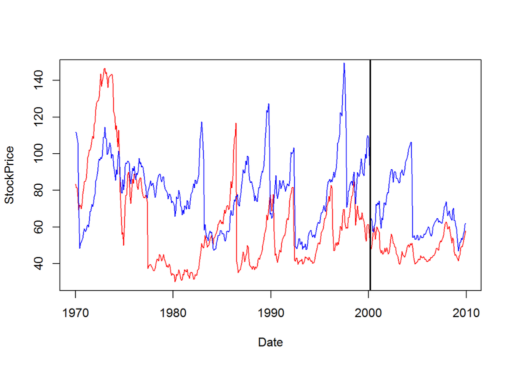

```r
plot(CocaCola, type = "l", col = "red")
lines(ProcterGamble$Date, ProcterGamble$StockPrice, col = "blue")
abline(v=as.Date(c("2000-03-01")), lwd=2)
```

### Problem 2.3 - Visualizing Stock Dynamics

Answer these questions using the plot you generated in the previous problem.

Around 1983, the stock for one of these companies (Coca-Cola or Procter and Gamble) was going up, while the other was going down. Which one was going up?

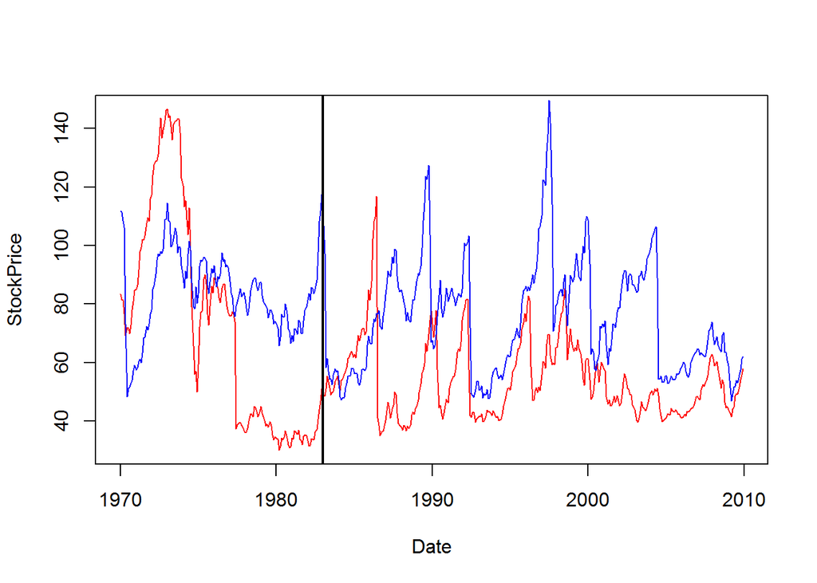

```r
plot(CocaCola, type = "l", col = "red")
lines(ProcterGamble$Date, ProcterGamble$StockPrice, col = "blue")
abline(v=as.Date(c("1983-01-01")), lwd=2)
```

### Problem 3.1 - Visualizing Stock Dynamics 1995-2005

(1 point possible) Let’s take a look at how the stock prices changed from 1995-2005 for all five companies. In your R console, start by typing the following plot command:

plot(CocaCola$Date[301:432], CocaCola$StockPrice[301:432], type=“l”, col=“red”, ylim=c(0,210))

This will plot the CocaCola stock prices from 1995 through 2005, which are the observations numbered from 301 to 432. The additional argument, ylim=c(0,210), makes the y-axis range from 0 to 210. This will allow us to see all of the stock values when we add in the other companies.

Now, use the lines function to add in the other four companies, remembering to only plot the observations from 1995 to 2005, or [301:432]. You don’t need the “type” or “ylim” arguments for the lines function, but remember to make each company a different color so that you can tell them apart. Some color options are “red”, “blue”, “green”, “purple”, “orange”, and “black”. To see all of the color options in R, type colors() in your R console.

(If you prefer to change the type of the line instead of the color, here are some options for changing the line type: lty=2 will make the line dashed, lty=3 will make the line dotted, lty=4 will make the line alternate between dashes and dots, and lty=5 will make the line long-dashed.)

Use this plot to answer the following four questions.

Which stock fell the most right after the technology bubble burst in March 2000?

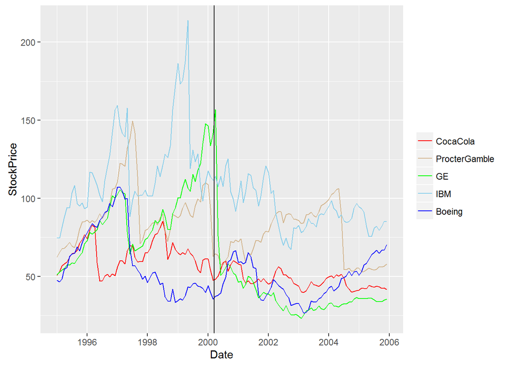

```r
library(ggplot2)
ggplot(data = CocaCola, aes(x = Date, y = StockPrice)) + geom_line(data = CocaCola[301:432,], aes (colour = "CocaCola")) + geom_line(data = ProcterGamble[301:432,], aes (colour = "ProcterGamble")) + geom_line(data = GE[301:432,], aes (colour = "GE")) + geom_line(data = IBM[301:432,], aes (colour = "IBM")) + geom_line(data = Boeing[301:432,], aes (colour = "Boeing")) + scale_color_manual("",breaks = c("CocaCola","ProcterGamble","GE","IBM","Boeing"), values = c("blue", "red","green","skyblue","tan")) + geom_vline(xintercept = as.numeric(as.Date("2000-03-15")))
```

### Problem 3.2 - Visualizing Stock Dynamics 1995-2005

Which stock reaches the highest value in the time period 1995-2005?

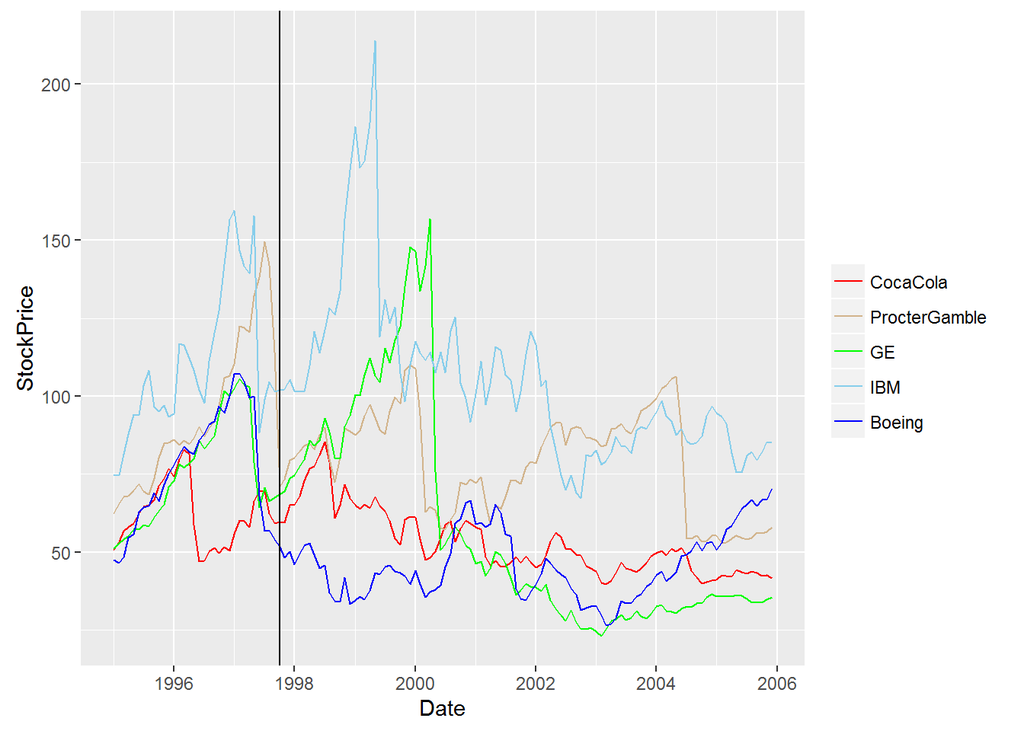

```r
library(ggplot2)
ggplot(data = CocaCola, aes(x = Date, y = StockPrice)) + geom_line(data = CocaCola[301:432,], aes (colour = "CocaCola")) + geom_line(data = ProcterGamble[301:432,], aes (colour = "ProcterGamble")) + geom_line(data = GE[301:432,], aes (colour = "GE")) + geom_line(data = IBM[301:432,], aes (colour = "IBM")) + geom_line(data = Boeing[301:432,], aes (colour = "Boeing")) + scale_color_manual("",breaks = c("CocaCola","ProcterGamble","GE","IBM","Boeing"), values = c("blue", "red","green","skyblue","tan")) + geom_vline(xintercept = as.numeric(as.Date("1997-10-01")))
```

In the last two years of this time period (2004 and 2005) which stock seems to be performing the best, in terms of increasing stock price?

### Problem 3.3 - Visualizing Stock Dynamics 1995-2005

In October of 1997, there was a global stock market crash that was caused by an economic crisis in Asia. Comparing September 1997 to November 1997, which companies saw a decreasing trend in their stock price? (Select all that apply.)

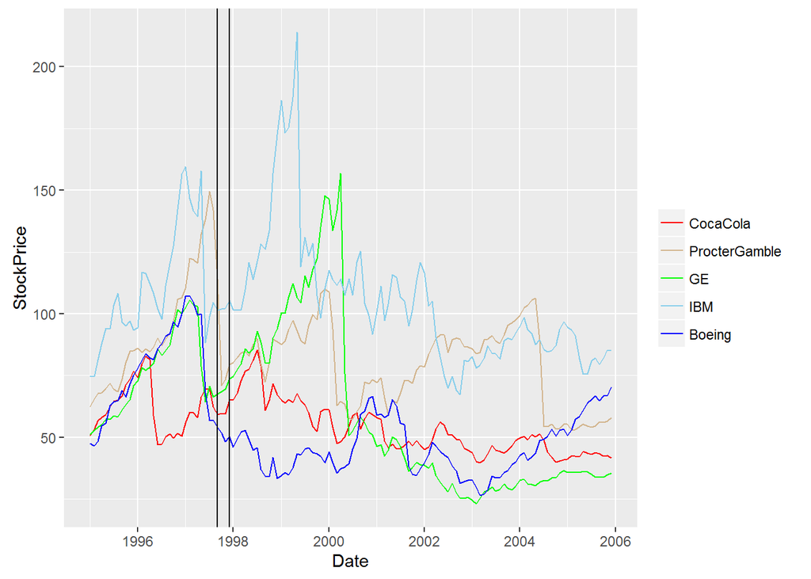

```r
ggplot(data = CocaCola, aes(x = Date, y = StockPrice)) + geom_line(data = CocaCola[301:432,], aes (colour = "CocaCola")) + geom_line(data = ProcterGamble[301:432,], aes (colour = "ProcterGamble")) + geom_line(data = GE[301:432,], aes (colour = "GE")) + geom_line(data = IBM[301:432,], aes (colour = "IBM")) + geom_line(data = Boeing[301:432,], aes (colour = "Boeing")) + scale_color_manual("",breaks = c("CocaCola","ProcterGamble","GE","IBM","Boeing"), values = c("blue", "red","green","skyblue","tan")) + geom_vline(xintercept = as.numeric(as.Date("1997-11-30"))) + geom_vline(xintercept = as.numeric(as.Date("1997-09-01")))
```

### Problem 3.4 - Visualizing Stock Dynamics 1995-2005

In the last two years of this time period (2004 and 2005) which stock seems to be performing the best, in terms of increasing stock price?

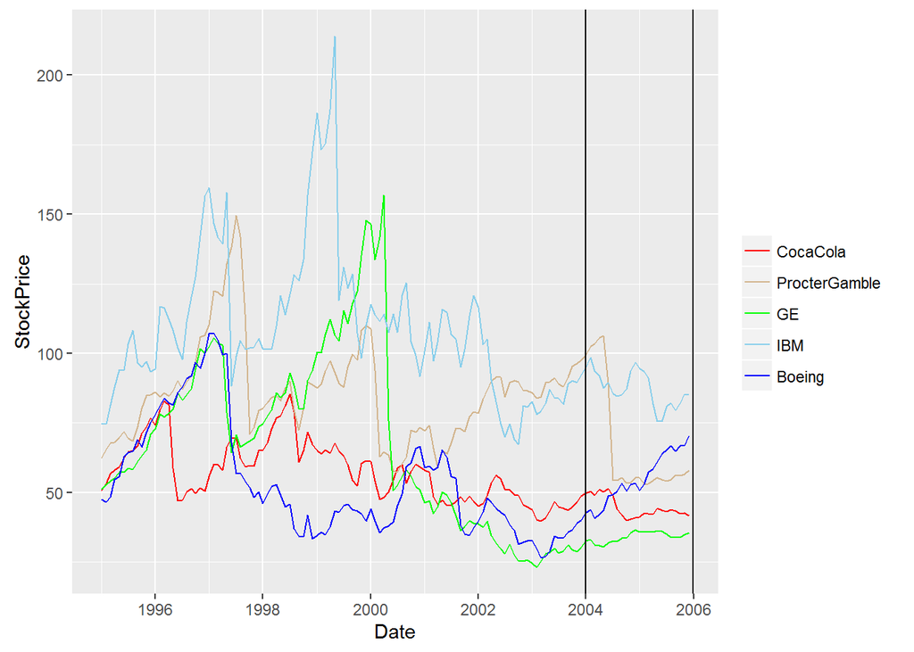

```r
ggplot(data = CocaCola, aes(x = Date, y = StockPrice)) + geom_line(data = CocaCola[301:432,], aes (colour = "CocaCola")) + geom_line(data = ProcterGamble[301:432,], aes (colour = "ProcterGamble")) + geom_line(data = GE[301:432,], aes (colour = "GE")) + geom_line(data = IBM[301:432,], aes (colour = "IBM")) + geom_line(data = Boeing[301:432,], aes (colour = "Boeing")) + scale_color_manual("",breaks = c("CocaCola","ProcterGamble","GE","IBM","Boeing"), values = c("blue", "red","green","skyblue","tan")) + geom_vline(xintercept = as.numeric(as.Date("2004-01-01"))) + geom_vline(xintercept = as.numeric(as.Date("2005-12-31")))
```

### Problem 4.1 - Monthly Trends

(1 point possible) Lastly, let’s see if stocks tend to be higher or lower during certain months. Use the tapply command to calculate the mean stock price of IBM, sorted by months. To sort by months, use

months(IBM$Date)

as the second argument of the tapply function.

For IBM, compare the monthly averages to the overall average stock price. In which months has IBM historically had a higher stock price (on average)? Select all that apply.

```r
monthPriceIBM <- tapply(IBM$StockPrice, months(IBM$Date), mean)/mean((IBM$StockPrice))
monthPriceIBM[monthPriceIBM>1]
```

```
##  helmikuu  huhtikuu maaliskuu  tammikuu  toukokuu
##  1.057621  1.053623  1.055811  1.040612  1.049366
```

Problem 4.2 - Monthly Trends

(1 point possible) Repeat the tapply function from the previous problem for each of the other four companies, and use the output to answer the remaining questions.

General Electric and Coca-Cola both have their highest average stock price in the same month. Which month is this?

```r
monthPriceGE <- tapply(GE$StockPrice, months(GE$Date), mean)/mean((GE$StockPrice))
monthPriceGE
```

```
##    elokuu  heinäkuu  helmikuu  huhtikuu  joulukuu   kesäkuu   lokakuu
## 0.9527793 0.9566634 1.0542514 1.0872897 0.9966051 0.9521940 0.9483245
## maaliskuu marraskuu   syyskuu  tammikuu  toukokuu
## 1.0648704 0.9660271 0.9483273 1.0462300 1.0264377
```

```r
monthPriceGE[which.max(monthPriceGE)]
```

```
## huhtikuu
##  1.08729
```

```r
monthPriceCocaCola <- tapply(CocaCola$StockPrice, months(CocaCola$Date), mean)/mean((CocaCola$StockPrice))
monthPriceCocaCola
```

```
##    elokuu  heinäkuu  helmikuu  huhtikuu  joulukuu   kesäkuu   lokakuu
## 0.9808496 0.9825708 1.0117446 1.0442973 0.9950441 1.0130328 0.9651696
## maaliskuu marraskuu   syyskuu  tammikuu  toukokuu
## 1.0340102 0.9845569 0.9595285 1.0056432 1.0235525
```

```r
monthPriceCocaCola[which.max(monthPriceCocaCola)]
```

```
## huhtikuu
## 1.044297
```

## Assingment III: DEMOGRAPHICS AND EMPLOYMENT IN THE UNITED STATES

In the wake of the Great Recession of 2009, there has been a good deal of focus on employment statistics, one of the most important metrics policymakers use to gauge the overall strength of the economy. In the United States, the government measures unemployment using the Current Population Survey (CPS), which collects demographic and employment information from a wide range of Americans each month. In this exercise, we will employ the topics reviewed in the lectures as well as a few new techniques using the September 2013 version of this rich, nationally representative dataset (available online).

The observations in the dataset represent people surveyed in the September 2013 CPS who actually completed a survey. While the full dataset has 385 variables, in this exercise we will use a more compact version of the dataset, CPSData.csv, which has the following variables:

PeopleInHousehold: The number of people in the interviewee’s household.

Region: The census region where the interviewee lives.

State: The state where the interviewee lives.

MetroAreaCode: A code that identifies the metropolitan area in which the interviewee lives (missing if the interviewee does not live in a metropolitan area). The mapping from codes to names of metropolitan areas is provided in the file MetroAreaCodes.csv.

Age: The age, in years, of the interviewee. 80 represents people aged 80-84, and 85 represents people aged 85 and higher.

Married: The marriage status of the interviewee.

Sex: The sex of the interviewee.

Education: The maximum level of education obtained by the interviewee.

Race: The race of the interviewee.

Hispanic: Whether the interviewee is of Hispanic ethnicity.

CountryOfBirthCode: A code identifying the country of birth of the interviewee. The mapping from codes to names of countries is provided in the file CountryCodes.csv.

Citizenship: The United States citizenship status of the interviewee.

EmploymentStatus: The status of employment of the interviewee.

Industry: The industry of employment of the interviewee (only available if they are employed).

Problem 1.1 - Loading and Summarizing the Dataset

(1 point possible) Load the dataset from CPSData.csv into a data frame called CPS, and view the dataset with the summary() and str() commands.

How many interviewees are in the dataset?

```r
#Again, let's start by emptying the workspace:
rm (list = ls(all=T))
```